# geodetector

2022/10/8

## 地理探测器$q$值与线性回归模型$R^2$的等价性

### 单因子探测

地理探测器主要是分析类型量（分类变量）的影响作用（解释力），假设$Y \sim X$，$Y$可以是连续变量，也可以是离散变量，但是一定得是定量数据；$X$可以是定性数据（分类变量），也可以是离散型的定量数据，若是连续型的定量数据，则需进行适当的离散化。

归根结底，这里是要将$Y$按照$X$进行分组（统计学术语中一般称为“层（strata）”），然后比较各层方差之和与总方差的差异性。

$$\begin{aligned}
&q=1-\frac{\sum_{h=1}^L N_h \sigma_h^2}{N \sigma^2}=1-\frac{S S W}{S
S T} \\
&S S W=\sum_{h=1}^L N_h \sigma_h^2, \quad S S T=N \sigma^2
\end{aligned}$$

然后，我们经过分析，发现这里地理探测器的$q$值本质上就是**同样处理后**的$X$对$Y$进行回归，得到的回归模型的$R^2$。

要证明证明这一点，首先假设$X$是分类变量，那么设$Y \sim X$得到的结果是什么？答：得到的结果是若干条与$x$轴平行的**线段**，每条线段对应$y$轴坐标为对应$X$分类那一组的组均值。

分类变量$X$对$Y$进行回归，要先将$X$转变为**虚拟变量**，这一过程相当于编码。假设$X$有四个分类（$a$、$b$、$c$、$d$），那我们可以进行如下编码：

| 分类 | $x_1$ | $x_2$ | $x_3$ |
| --- | --- | --- | --- |
| $a$ | 0 | 0 | 0 |
| $b$ | 1 | 0 | 0 |
| $c$ | 0 | 1 | 0 |
| $d$ | 0 | 0 | 1 |

$n$个分类只需引入$n-1$个虚拟变量，此处取$x_1=0$，$x_2=0$，$x_3=0$即为$a$类别，取$x_1=0$，$x_2=0$，$x_3=1$即为$d$类别。

然后我们就可以，构建回归模型：

$$\begin{eqnarray}
Y & = & \alpha+\beta_1 x_1+\beta_2 x_2+\beta_3 x_3+\varepsilon
\\
Y_i & = & \alpha+\beta_1 x_{1i}+\beta_2 x_{2i}+\beta_3
x_{3i}+\varepsilon_i
\end{eqnarray}$$

这里有两条路可以走：

一种方法是待定系数法，假设$Y_i=\alpha+\beta_1 x_{1i}+\beta_2 x_{2i}+\beta_3 x_{3i}+\varepsilon_i$里面的$\alpha$、$\beta_1$、$\beta_2$、$\beta_3$都已经求出来了，就是$a_0$、$b_1$、$b_2$、$b_3$，然后可知：

对于$a$类别，$x_1=0$，$x_2=0$，$x_3=0$，

$$\hat{Y}_i=a_0$$

两边求期望，显然有
$$E(Y_i|x_1=0,x_2=0,x_3=0)=a_0$$

$a_0$的意义就是$a$类别的组均值。

同理，对于$b$类别，$x_1=1$，$x_2=0$，$x_3=0$，

$$\begin{aligned}
\hat{Y}_{i} &=a_{0}+b_{1} \\
E\left(Y_{i} \mid x_{1}=1, x_{2}\right.&\left.=0,
x_{3}=0\right)=a_{0}+b_{1}
\end{aligned}$$

对于$c$类别，$x_1=0$，$x_2=1$，$x_3=0$，

$$\begin{aligned}
\hat{Y}_{i} &=a_{0}+b_{2} \\
E\left(Y_{i} \mid x_{1}=0, x_{2}\right.&\left.=1,
x_{3}=0\right)=a_{0}+b_{2}
\end{aligned}$$

另一种方法是通过整理样本构建$\boldsymbol{X}$，最上面先排$n_1$个$a$类别，即$n_1$行$(0, 0, 0)$，然后依次是$n_2$个$b$类别……

$$\boldsymbol{X}=\begin{bmatrix}
\left.\begin{matrix}
1,0,0,0\\
\cdots
\end{matrix}\right\} & n_1\\
\left.\begin{matrix}
1,1,0,0\\
\cdots
\end{matrix}\right\} & n_2\\
\left.\begin{matrix}
1,0,1,0\\
\cdots
\end{matrix}\right\} & n_3\\
\left.\begin{matrix}
1,0,0,1\\
\cdots
\end{matrix}\right\} & n_4
\end{bmatrix}=\begin{bmatrix}
\boldsymbol{1}_{n_1} & \boldsymbol{0}_{n_1} &
\boldsymbol{0}_{n_1} & \boldsymbol{0}_{n_1}\\
\boldsymbol{1}_{n_2} & \boldsymbol{1}_{n_2} &
\boldsymbol{0}_{n_2} & \boldsymbol{0}_{n_2}\\
\boldsymbol{1}_{n_3} & \boldsymbol{0}_{n_3} &
\boldsymbol{1}_{n_3} & \boldsymbol{0}_{n_3}\\
\boldsymbol{1}_{n_4} & \boldsymbol{0}_{n_4} &
\boldsymbol{0}_{n_4} & \boldsymbol{1}_{n_4}
\end{bmatrix}$$

然后最小二乘法求解，得到的最终公式是：

$$\boldsymbol{\hat{\beta}}=(\boldsymbol{X^{'}X})^{-1}\boldsymbol{X^{'}Y}$$

由此，

$$\boldsymbol{\hat{\beta}}=(\boldsymbol{X^{'}X})^{-1}\boldsymbol{X^{'}Y}
=\begin{bmatrix}
\frac{1}{n_1}\cdot\sum_{i}^{n_1}y_{n_1i}\\
-\frac{1}{n_1}\cdot\sum_{i}^{n_1}y_{n_1i}+\frac{1}{n_2}\cdot\sum_{i}^{n_2}y_{n_2i}\\
-\frac{1}{n_1}\cdot\sum_{i}^{n_1}y_{n_1i}+\frac{1}{n_3}\cdot\sum_{i}^{n_3}y_{n_3i}\\
-\frac{1}{n_1}\cdot\sum_{i}^{n_1}y_{n_1i}+\frac{1}{n_4}\cdot\sum_{i}^{n_4}y_{n_4i}
\end{bmatrix}$$

于是，

$$\begin{array}{c}
\hat{Y}_{i}=\left(1, x_{1 i}, x_{2 i}, x_{3 i}\right) \cdot
\hat{\boldsymbol{\beta}}=\frac{1}{n_{1}} \cdot \sum_{i}^{n_{1}} y_{n i
i}+\left(-\frac{1}{n_{1}} \cdot \sum_{i}^{n_{1}} y_{n
1^{i}}+\frac{1}{n_{2}} \cdot \sum_{i}^{n_{2}} y_{n 2^{i}}\right) x_{1 i}
\\
+\left(-\frac{1}{n_{1}} \cdot \sum_{i}^{n_{1}} y_{n
1^{i}}+\frac{1}{n_{3}} \cdot \sum_{i}^{n_{3}} y_{n 3^{i}}\right) x_{2
i}+\left(-\frac{1}{n_{1}} \cdot \sum_{i}^{n_{1}} y_{n i
i}+\frac{1}{n_{4}} \cdot \sum_{i}^{n_{4}} y_{n 4^{i}}\right) x_{3 i}
\end{array}$$

将不同组别的虚拟变量值代入后，显然也是，**对于只包含一个分类变量$X$的回归方程，$Y \sim X$，函数拟合值就是不同组别的组均值**。这里是4个类别，$n$个类别同理。

明确这点后，我们自然可以计算$R^2$，与$q$值计算保持一致，假设我们自变量有$L$个类别，或者说$L$层。

$$R^2=1-\frac{\sum(y_i-\hat{y}_i)^2}{\sum(y_i-\bar{y})^2}$$

$\sum(y_i-\hat{y}_i)^2$代表**未被模型解释变化**，$\sum(y_i-\bar{y})^2$代表**数据差异变化**。我们以$\bar{y}_h$表示第$h$个类别的组均值。

$$\begin{array}{c}
R^{2}=1-\frac{\sum\left(y_{i}-\hat{y}_{i}\right)^{2}}{\sum\left(y_{i}-\bar{y}\right)^{2}}=1-\frac{\sum_{h=1}^{L}
\sum\left(y_{i}-\bar{y}_{h}\right)^{2}}{\sum\left(y_{i}-\bar{y}\right)^{2}}
\\
=1-\frac{\sum_{h=1}^{L} N_{h} \cdot \frac{1}{N_{h}}
\sum\left(y_{i}-\bar{y}_{h}\right)^{2}}{N \cdot \frac{1}{N}
\sum\left(y_{i}-\bar{y}\right)^{2}}=1-\frac{\sum_{h=1}^{L} N_{h}
\sigma_{h}^{2}}{N \sigma^{2}}=q
\end{array}$$

可以进行一下实证模拟：

使用地理探测器，

```r
factor_detector("incidence", "elevation", CollectData)
```

```
## [[1]]
##           q-statistic    p-value
## elevation   0.6067087 0.04080407
```

使用lm函数，将$elevation$转变为因子变量，对$incidence$进行回归，

```r
fit_1 <- lm(incidence ~ factor(elevation), data = CollectData)
summary(fit_1)
```

```
##
## Call:
## lm(formula = incidence ~ factor(elevation), data = CollectData)
##
## Residuals:
##      Min       1Q   Median       3Q      Max
## -0.50588 -0.13811 -0.02889  0.07412  1.29189
##
## Coefficients:
##                    Estimate Std. Error t value Pr(>|t|)
## (Intercept)         6.45588    0.02874 224.628  < 2e-16 ***
## factor(elevation)2 -0.28477    0.08407  -3.388 0.000868 ***
## factor(elevation)3 -0.19777    0.04842  -4.085 6.66e-05 ***
## factor(elevation)4  0.16548    0.05813   2.847 0.004936 **
## factor(elevation)5 -0.54699    0.06282  -8.707 2.08e-15 ***
## factor(elevation)6  0.43275    0.05813   7.445 4.02e-12 ***
## factor(elevation)7 -0.66588    0.08407  -7.921 2.46e-13 ***
## ---
## Signif. codes:  0 '***' 0.001 '**' 0.01 '*' 0.05 '.' 0.1 ' ' 1
##
## Residual standard error: 0.237 on 178 degrees of freedom
## Multiple R-squared:  0.6067, Adjusted R-squared:  0.5935
## F-statistic: 45.77 on 6 and 178 DF,  p-value: < 2.2e-16
```

### 交互因子探测

地理探测器交互因子探测是识别不同风险因子之间的交互作用，即评估因子$X$和$Z$共同作用时是否会增加或减弱对因变量$Y$的解释力，或这些因子对$Y$的影响是相互独立的。在算法上的实际操作是，将数据按两个分类变量$X$和$Z$进行交叉分组，若$X$有三个分类，$Z$有两个分类，交叉之下，就有了六个分类。然后，对这种新的分类方式进行如上所述的单因子探测，比较这种新分类是否比两个原始分类有更强的解释性。

而这种交叉分类的处理方式，也是lm函数对于两个分类变量交互的处理方式，因此，这种情况下，地理探测器$q$值与线性回归模型$R^2$依然是等价的。以实证数据验证一下：

使用地理探测器，

```r
interaction_detector("incidence", c("soiltype", "elevation"), CollectData)
```

```
##      [,1]        [,2]        [,3]
## [1,] "soiltype"  "elevation" "0.663523698335635"
## [2,] "soiltype"  "soiltype"  "0.385716842809428"
## [3,] "elevation" "elevation" "0.606708709727727"
```

使用lm函数，将$elevation$和$soiltype$转变为因子变量，对$incidence$进行回归，

```r
fit_2 <- lm(incidence ~ factor(soiltype) * factor(elevation), data = CollectData)
summary(fit_2)
```

```
##
## Call:
## lm(formula = incidence ~ factor(soiltype) * factor(elevation),
##     data = CollectData)
##
## Residuals:
##      Min       1Q   Median       3Q      Max
## -0.45000 -0.13625 -0.02231  0.06167  1.20375
##
## Coefficients: (17 not defined because of singularities)
##                                      Estimate Std. Error t value Pr(>|t|)
## (Intercept)                           6.42412    0.03881 165.514  < 2e-16 ***
## factor(soiltype)2                     0.31588    0.08484   3.723 0.000268 ***
## factor(soiltype)3                    -0.10566    0.07380  -1.432 0.154111
## factor(soiltype)4                    -0.09917    0.14609  -0.679 0.498193
## factor(soiltype)5                     0.05755    0.07599   0.757 0.449934
## factor(elevation)2                   -0.30167    0.10764  -2.803 0.005668 **
## factor(elevation)3                   -0.22181    0.07380  -3.006 0.003060 **
## factor(elevation)4                    0.10833    0.23556   0.460 0.646187
## factor(elevation)5                   -0.44078    0.13631  -3.234 0.001473 **
## factor(elevation)6                    0.14833    0.17285   0.858 0.392041
## factor(elevation)7                   -0.53495    0.16894  -3.167 0.001834 **
## factor(soiltype)2:factor(elevation)2       NA         NA      NA       NA
## factor(soiltype)3:factor(elevation)2  0.12321    0.20282   0.607 0.544367
## factor(soiltype)4:factor(elevation)2       NA         NA      NA       NA
## factor(soiltype)5:factor(elevation)2       NA         NA      NA       NA
## factor(soiltype)2:factor(elevation)3       NA         NA      NA       NA
## factor(soiltype)3:factor(elevation)3  0.07585    0.12565   0.604 0.546909
## factor(soiltype)4:factor(elevation)3       NA         NA      NA       NA
## factor(soiltype)5:factor(elevation)3  0.08639    0.11365   0.760 0.448219
## factor(soiltype)2:factor(elevation)4 -0.31833    0.27974  -1.138 0.256760
## factor(soiltype)3:factor(elevation)4  0.21154    0.24955   0.848 0.397823
## factor(soiltype)4:factor(elevation)4       NA         NA      NA       NA
## factor(soiltype)5:factor(elevation)4       NA         NA      NA       NA
## factor(soiltype)2:factor(elevation)5       NA         NA      NA       NA
## factor(soiltype)3:factor(elevation)5       NA         NA      NA       NA
## factor(soiltype)4:factor(elevation)5       NA         NA      NA       NA
## factor(soiltype)5:factor(elevation)5 -0.10755    0.19980  -0.538 0.591104
## factor(soiltype)2:factor(elevation)6       NA         NA      NA       NA
## factor(soiltype)3:factor(elevation)6  0.44771    0.19073   2.347 0.020083 *
## factor(soiltype)4:factor(elevation)6       NA         NA      NA       NA
## factor(soiltype)5:factor(elevation)6       NA         NA      NA       NA
## factor(soiltype)2:factor(elevation)7       NA         NA      NA       NA
## factor(soiltype)3:factor(elevation)7       NA         NA      NA       NA
## factor(soiltype)4:factor(elevation)7       NA         NA      NA       NA
## factor(soiltype)5:factor(elevation)7       NA         NA      NA       NA
## ---
## Signif. codes:  0 '***' 0.001 '**' 0.01 '*' 0.05 '.' 0.1 ' ' 1
##
## Residual standard error: 0.2263 on 167 degrees of freedom
## Multiple R-squared:  0.6635, Adjusted R-squared:  0.6293
## F-statistic: 19.37 on 17 and 167 DF,  p-value: < 2.2e-16
```

## 空间异质性与自相关性并存情形下地理探测器$q$值的有效性

前文已经论述了OLS回归得到的R<sup>2</sup>等价于$q$：$q$=OLS-R<sup>2</sup>。从$q$值的计算公式来看，组内方差和总方差计算的隐含假设为y是随机分布，无显著的整体或者层内空间自相关或联系效应。因为$q$统计量和R<sup>2</sup>都是测度贡献度的，我们考虑在y有不同空间自相关情形下，$q$和R<sup>2</sup>的差异关系。  
以spdata包内置的北卡罗来纳州（North Carolina）的拓扑结构构建邻接矩阵

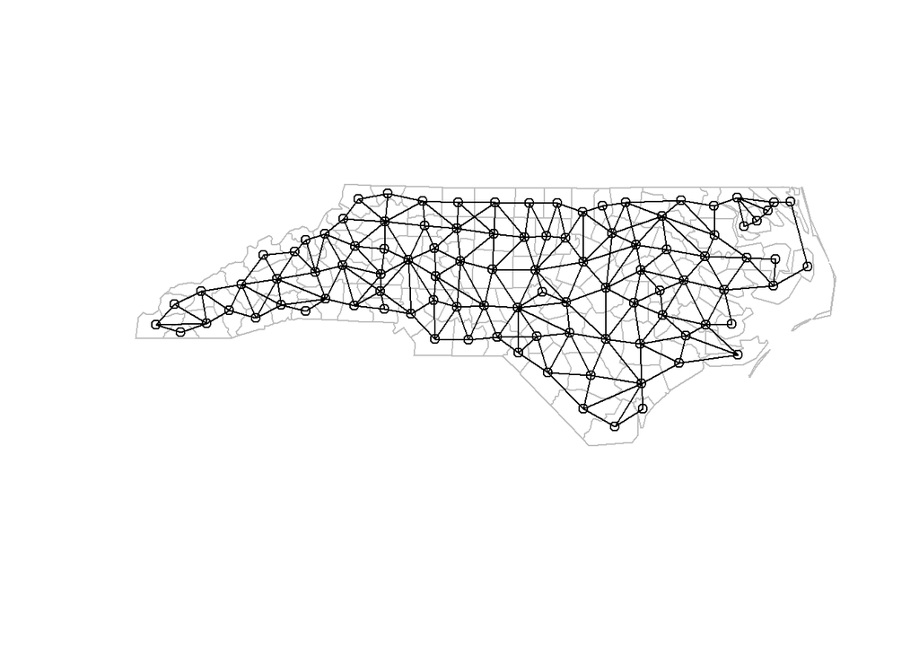

```r
library(geodetector)
library(spdep)
library(spatialreg)
nc <- st_read(system.file("shapes/sids.shp", package="spData")[1], quiet=TRUE)
st_crs(nc) <- "+proj=longlat +datum=NAD27"
row.names(nc) <- as.character(nc$FIPSNO)
# neighbourhood structure and weights matrix
nb_nc <- spdep::poly2nb(nc)
lisw_nc <- spdep::nb2listw(nb_nc, style = "W", zero.policy = TRUE)
plot(st_geometry(nc),border = 'grey')
plot( st_centroid(nc$geometry), add=TRUE )
plot(lisw_nc, st_centroid(nc$geometry), add= TRUE )
```

### 3.1 单因子

构建一个具有空间滞后形式的空间自回归数据产生过程（spatial lag model），$x$为三类别的分类变量.

$$y_i=ρW_{i}y_i+γ_1+γ_2 x_{2i}+γ_3 x_{3i}+μ_i; \,μ_i \sim (0,σ_μ^2)$$

可以得到$y$的产生过程：
$$y_i=(I-ρW_i)^{-1} (γ_1 I+γ_2 x_{2i}+γ_3 x_{3i}+μ_i); \,
μ_{i}\sim(0,σ_μ^2)$$

不失一般性地将模拟参数设置为：
$$ρ∈\operatorname{seq}(0.05,0.95,\operatorname{by}=0.05); \,
μ_{i}\sim(0,0.1); \, \mathbf{γ}=(1,1.5,1)$$

在模拟实验中，由于$y$具有空间效应，并且真实的空间效应为$ρWy$,那么理论上$x$需要解释的部分为$\tilde{y}=y-ρWy$，真实$R^2$则为

$$R^{2}=1-\frac{\sum\left(\tilde{y_i}-\hat{\gamma}_{1} I+\hat{\gamma}_{2}
x_{2i}+\hat{\gamma}_{3} x_{3i}\right)}{\sum (\tilde{y_i}-\bar{y_i})}$$

其中：$ρ$为预设，$\hat{\gamma}_{1}$,$\hat{\gamma}_{2}$和$\hat{\gamma}_{3}$为OLS估计。

每个$\rho$模拟100次，取均值，观察*q*相对于真实R<sup>2</sup>的偏差